# Google Data Analytics Capstone Project - Bellabeat

Lin Jiaming

7 June 2021

## Description

**Activity:** Data Analysis, Data Visualisation  
**Dataset:** FitBit Fitness Tracker Data (Kaggle)  
**Table:** dailyActivity_clean.csv, sleepDay_clean.csv

### Load Libraries

```r
library(tidyverse)
library(ggplot2)
library(lubridate)
```

### Import Data

```r
activity_df = read_csv('dailyActivity_clean.csv')
sleep_df = read_csv('sleepDay_clean.csv')
```

### Inspect Data

Inspect column header and data type only

Data is cleaned prior this activity, refer to:

- Bellabeat_dailyActivity_clean.html
- Bellabeat_sleepDay_clean.html

```r
glimpse(activity_df)
```

```
## Rows: 940
## Columns: 15
## $ id                         <dbl> 1503960366, 1503960366, 1503960366, 1503960~
## $ activity_date              <date> 2016-04-12, 2016-04-13, 2016-04-14, 2016-0~
## $ total_steps                <dbl> 13162, 10735, 10460, 9762, 12669, 9705, 130~
## $ total_distance             <dbl> 8.50, 6.97, 6.74, 6.28, 8.16, 6.48, 8.59, 9~
## $ tracker_distance           <dbl> 8.50, 6.97, 6.74, 6.28, 8.16, 6.48, 8.59, 9~
## $ logged_activities_distance <dbl> 0, 0, 0, 0, 0, 0, 0, 0, 0, 0, 0, 0, 0, 0, 0~
## $ very_active_distance       <dbl> 1.88, 1.57, 2.44, 2.14, 2.71, 3.19, 3.25, 3~
## $ moderately_active_distance <dbl> 0.55, 0.69, 0.40, 1.26, 0.41, 0.78, 0.64, 1~
## $ light_active_distance      <dbl> 6.06, 4.71, 3.91, 2.83, 5.04, 2.51, 4.71, 5~
## $ sedentary_active_distance  <dbl> 0, 0, 0, 0, 0, 0, 0, 0, 0, 0, 0, 0, 0, 0, 0~
## $ very_active_minutes        <dbl> 25, 21, 30, 29, 36, 38, 42, 50, 28, 19, 66,~
## $ fairly_active_minutes      <dbl> 13, 19, 11, 34, 10, 20, 16, 31, 12, 8, 27, ~
## $ lightly_active_minutes     <dbl> 328, 217, 181, 209, 221, 164, 233, 264, 205~
## $ sedentary_minutes          <dbl> 728, 776, 1218, 726, 773, 539, 1149, 775, 8~
## $ calories                   <dbl> 1985, 1797, 1776, 1745, 1863, 1728, 1921, 2~
```

```r
glimpse(sleep_df)
```

```
## Rows: 410
## Columns: 5
## $ id                   <dbl> 1503960366, 1503960366, 1503960366, 1503960366, 1~
## $ sleep_day            <date> 2016-04-12, 2016-04-13, 2016-04-15, 2016-04-16, ~
## $ total_sleep_records  <dbl> 1, 2, 1, 2, 1, 1, 1, 1, 1, 1, 1, 1, 1, 1, 1, 1, 1~
## $ total_minutes_asleep <dbl> 327, 384, 412, 340, 700, 304, 360, 325, 361, 430,~
## $ total_time_in_bed    <dbl> 346, 407, 442, 367, 712, 320, 377, 364, 384, 449,~
```

```r
# Update data types to factor, for visualisation purposes
activity_df$id <- factor(activity_df$id)
sleep_df$id <- factor(sleep_df$id)
sleep_df$total_sleep_records <- factor(sleep_df$total_sleep_records)
```

## Summary Descriptions

**Activity Table:**

- Total records = 940
- Unique users = 33
- Unique dates = 31
- Start date = 2016-04-12
- End date = 2016-05-12

**Sleep Table:**

- Total records = 410
- Unique users = 24
- Unique dates = 31
- Start date = 2016-04-12
- End date = 2016-05-12

```r
activity_df %>% summarise(record_cnt = nrow(.),
                          user_cnt = n_distinct(.$id),
                          date_cnt = n_distinct(.$activity_date),
                          user_date_cnt = n_distinct(.$id, .$activity_date),
                          start_date = min(.$activity_date),
                          end_date = max(.$activity_date))
```

```
## # A tibble: 1 x 6
##   record_cnt user_cnt date_cnt user_date_cnt start_date end_date
##        <int>    <int>    <int>         <int> <date>     <date>
## 1        940       33       31           940 2016-04-12 2016-05-12
```

```r
sleep_df %>% summarise(record_cnt = nrow(.),
                       user_cnt = n_distinct(.$id),
                       date_cnt = n_distinct(.$sleep_day),
                       user_date_cnt = n_distinct(.$id, .$sleep_day),
                       start_date = min(.$sleep_day),
                       end_date = max(.$sleep_day))
```

```
## # A tibble: 1 x 6
##   record_cnt user_cnt date_cnt user_date_cnt start_date end_date
##        <int>    <int>    <int>         <int> <date>     <date>
## 1        410       24       31           410 2016-04-12 2016-05-12
```

## Visualisations

#### User Activity: Tracking *Total Steps*

33 users tracked their data  
21 out of 33 users (64%) tracked their data for **all days** – *see non-blank rows in visual*  
All users tracked their data in **running days**

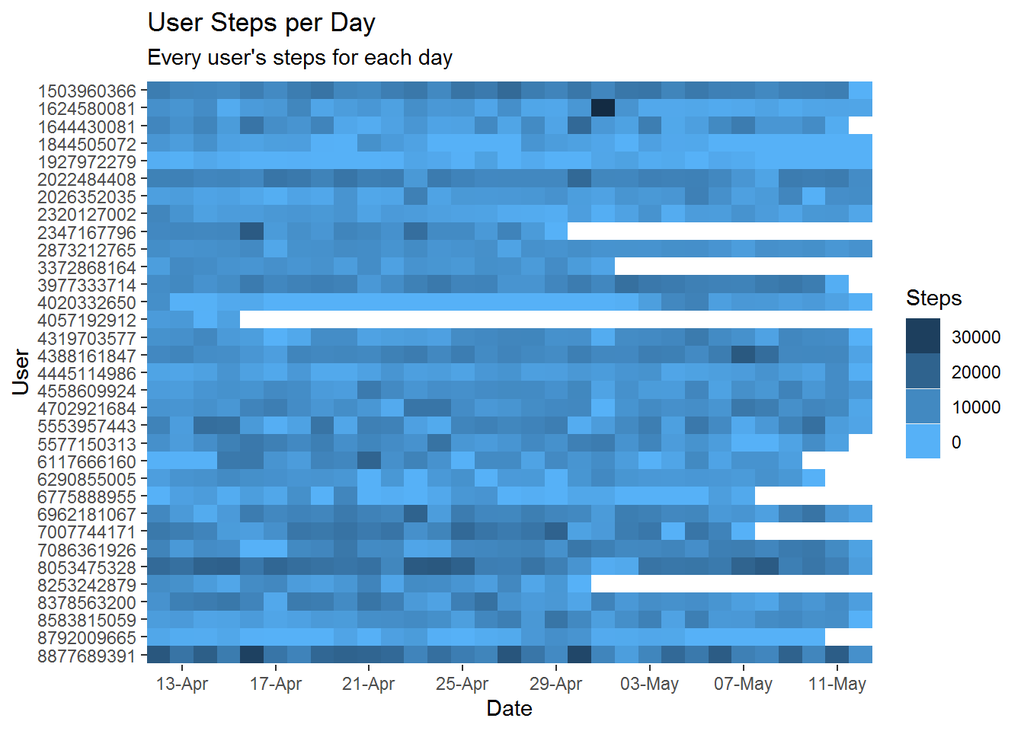

```r
# Y-axis shows the id of all 33 users
ggplot(activity_df) +
  geom_tile(aes(activity_date, id, fill = total_steps)) +
  scale_fill_continuous(trans = 'reverse') +                # reverse fill scale
  theme(panel.grid = element_blank(),
        panel.background = element_blank()) +
  labs(title = 'User Steps per Day',
       subtitle = "Every user's steps for each day",
       x = 'Date', y = 'User',
       fill = 'Steps') +                                    # rename legend
  guides(fill = guide_legend(reverse = TRUE)) +             # reverse legend
  scale_x_date(date_breaks = '4 day',
               date_labels = '%d-%b',
               expand = c(0,0)) +                           # fill gap between axis and plot
  scale_y_discrete(limits = rev)                            # reverse y-axis
```

```r
activity_df %>%
  group_by(id) %>%
  summarise(days_tracked = length(activity_date)) %>%
  group_by(days_tracked) %>%
  summarise(user_count = length(id)) %>%
  arrange(-days_tracked)
```

```
## # A tibble: 9 x 2
##   days_tracked user_count
##          <int>      <int>
## 1           31         21
## 2           30          3
## 3           29          2
## 4           28          1
## 5           26          2
## 6           20          1
## 7           19          1
## 8           18          1
## 9            4          1
```

#### User Activity: Tracking *Total Steps*

77 out of 940 records (8%) registered **total steps of 0** for the entire day

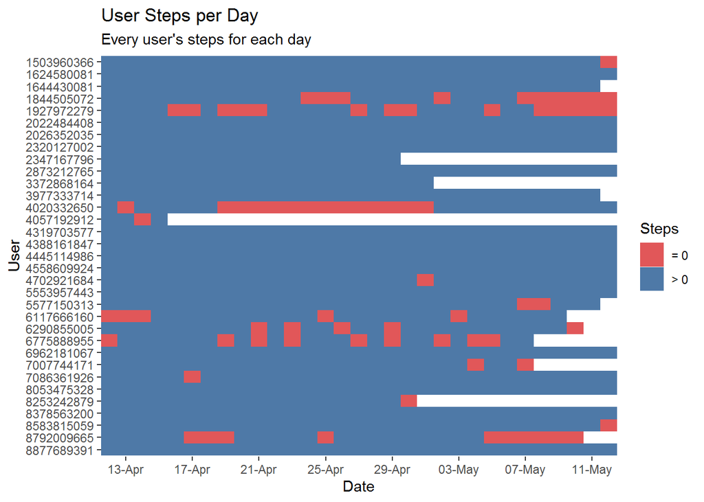

```r
# Convert steps to discrete variable
activity_df_steps <- activity_df %>%
  mutate(category = if_else(total_steps == 0, '= 0', '> 0'))

# Y-axis shows the id of all 33 users
ggplot(activity_df_steps) +
  geom_tile(aes(activity_date, id, fill = category)) +
  scale_fill_manual(values = c('#e15759', '#4e79a7')) +
  theme(panel.grid = element_blank(),
        panel.background = element_blank()) +
  labs(title = 'User Steps per Day',
       subtitle = "Every user's steps for each day",
       x = 'Date', y = 'User',
       fill = 'Steps') +                                # rename legend
  scale_x_date(date_breaks = '4 day',
               date_labels = '%d-%b',
               expand = c(0,0)) +                       # fill gap between axis and plot
  scale_y_discrete(limits = rev)                        # reverse y-axis
```

```r
activity_df %>%
  filter(total_steps == 0) %>%
  nrow()
```

```
## [1] 77
```

#### User Activity: Tracking *Sleep*

24 out of 33 users (73%) tracked their sleep  
3 out of 33 users (9%) tracked their sleep data for **all days** – *see non-blank rows in visual*  
5 out of 33 users (15%) tracked their sleep data in **running days**

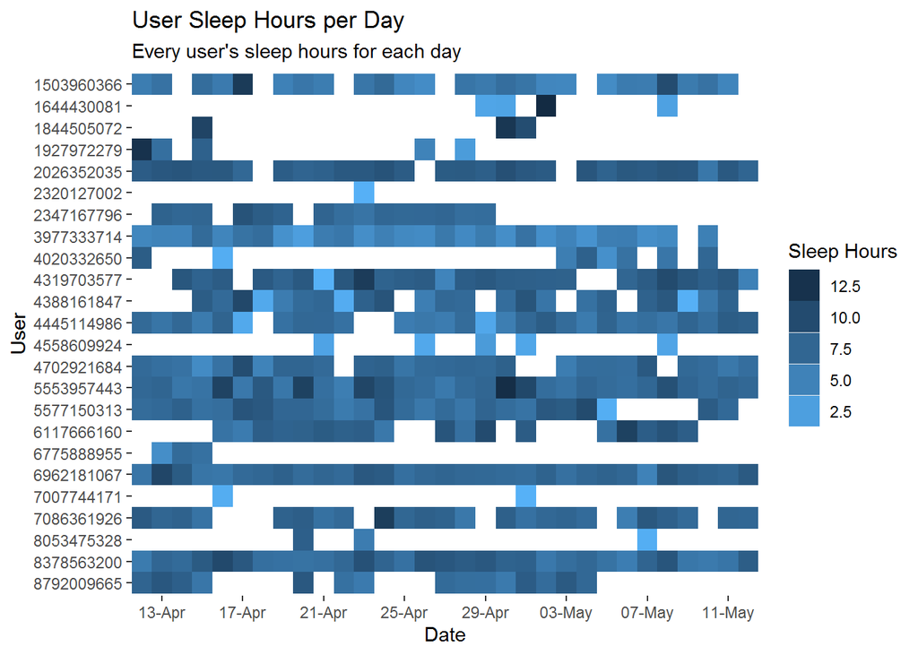

```r
# Y-axis shows the id of 24 users who tracked their sleep
ggplot(sleep_df) +
  geom_tile(aes(sleep_day, id, fill = total_minutes_asleep/60)) +
  scale_fill_continuous(trans = 'reverse') +            # reverse fill scale
  theme(panel.grid = element_blank(),
        panel.background = element_blank()) +
  labs(title = 'User Sleep Hours per Day',
       subtitle = "Every user's sleep hours for each day",
       x = 'Date', y = 'User',
       fill = 'Sleep Hours') +                          # rename legend
  guides(fill = guide_legend(reverse = TRUE)) +         # reverse legend
  scale_x_date(date_breaks = '4 day',
               date_labels = '%d-%b',
               expand = c(0,0)) +                       # fill gap between axis and plot
  scale_y_discrete(limits = rev)                        # reverse y-axis
```

```r
sleep_df %>%
  group_by(id) %>%
  summarise(days_tracked = length(sleep_day)) %>%
  group_by(days_tracked) %>%
  summarise(user_count = length(id)) %>%
  arrange(-days_tracked)
```

```
## # A tibble: 15 x 2
##    days_tracked user_count
##           <int>      <int>
##  1           31          3
##  2           28          3
##  3           27          1
##  4           26          2
##  5           25          1
##  6           24          1
##  7           23          1
##  8           18          1
##  9           15          2
## 10            8          1
## 11            5          2
## 12            4          1
## 13            3          3
## 14            2          1
## 15            1          1
```

```r
# 24 users tracked their sleep data
# 5 users tracked their sleep data in running days
# 19 users did not track their sleep data in running days
sleep_df %>%
  group_by(id) %>%
  summarise(date_diff = sleep_day - lag(sleep_day, 1)) %>%
  filter(date_diff != 1) %>%
  distinct(id) %>%
  nrow()
```

```
## [1] 19
```

#### Filter Data

```r
activity_filter_df <- activity_df %>%
  filter(total_steps != 0 | total_distance != 0)
```

#### User Profile: Users by *Steps*

- 7 inactive users (21%)
- 19 active users (58%)
- 7 very active users (21%)

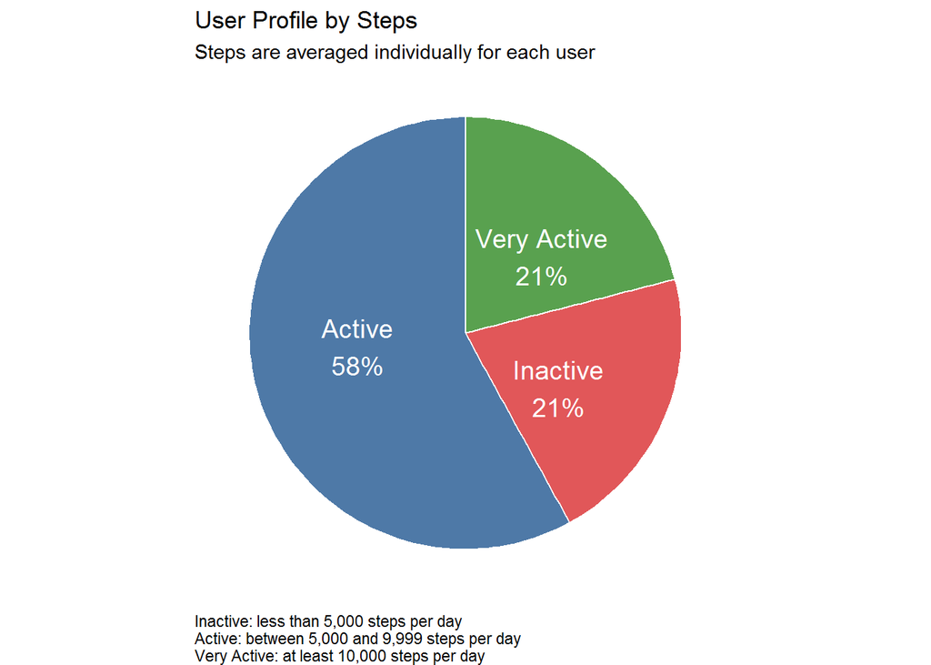

```r
activity_df_profile <- activity_filter_df %>%
  group_by(id) %>%
  summarise(user_avg_steps = mean(total_steps)) %>%                         # average steps for each user
  mutate(user_profile = case_when(user_avg_steps < 5000 ~ 'Inactive',
                                  user_avg_steps >= 10000 ~ 'Very Active',
                                  TRUE ~ 'Active')) %>%                     # classify each user profile
  group_by(user_profile) %>%
  summarise(user_count = n_distinct(id)) %>%
  mutate(percent = round(user_count / sum(.$user_count) * 100)) %>%         # calculate percentage
  mutate(y_position = 100 - (cumsum(percent) - 0.5*percent) + 2)            # position of each pie segment

ggplot(activity_df_profile) +
  geom_bar(aes('', percent, fill = user_profile),
           stat = 'identity',
           width = 1,
           colour = 'white') +
  coord_polar('y', start = 0) +                                             # create pie chart
  scale_fill_manual(values = c('#4e79a7', '#e15759', '#59a14f')) +
  theme_void() +
  theme(legend.position = 'none',
        plot.caption = element_text(hjust = 0)) +
  labs(title = 'User Profile by Steps',
       subtitle = 'Steps are averaged individually for each user',
       caption = 'Inactive: less than 5,000 steps per day \nActive: between 5,000 and 9,999 steps per day \nVery Active: at least 10,000 steps per day') +
  geom_text(aes('', y = y_position, label = paste0(user_profile,'\n',percent,'%')),
            color = 'white',
            size = 5)
```

#### User Profile: Users by *Steps*

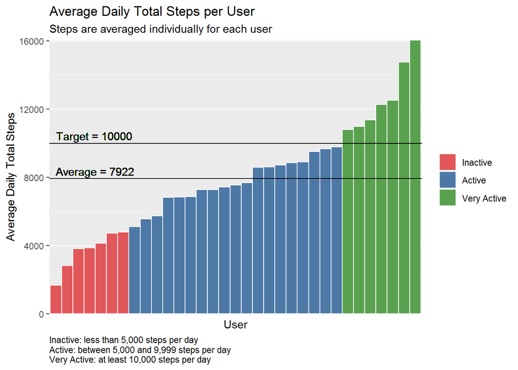

```r
activity_df_user_steps <- activity_filter_df %>%
  group_by(id) %>%
  summarise(user_avg_steps = mean(total_steps)) %>%                 # average steps for each user
  mutate(user_profile = case_when(user_avg_steps < 5000 ~ 'Inactive',
                                  user_avg_steps >= 10000 ~ 'Very Active',
                                  TRUE ~ 'Active'))                 # classify each user

ggplot(activity_df_user_steps) +
  geom_bar(aes(reorder(id, user_avg_steps), user_avg_steps,         # reorder bars by steps
               fill = factor(user_profile, levels = c('Inactive', 'Active', 'Very Active'))),
           stat = 'identity',
           width = 1,
           colour = 'white') +                                      # reorder legend by refactor user_profile
  scale_fill_manual(values = c('#e15759', '#4e79a7', '#59a14f')) +
  theme(axis.text.x = element_blank(),
        axis.ticks.x = element_blank(),
        panel.grid.major.x = element_blank(),
        panel.grid.minor.x = element_blank(),
        legend.title = element_blank(),
        plot.caption = element_text(hjust = 0)) +
  labs(title = 'Average Daily Total Steps per User',
       subtitle = 'Steps are averaged individually for each user',
       x = 'User', y = 'Average Daily Total Steps',
       caption = 'Inactive: less than 5,000 steps per day \nActive: between 5,000 and 9,999 steps per day \nVery Active: at least 10,000 steps per day') +
  scale_y_continuous(expand = c(0,0)) +                             # fill gap between axis and plot
  geom_hline(aes(yintercept = mean(user_avg_steps))) +              # add average line
  geom_text(aes(min(as.numeric(id)), mean(user_avg_steps),
                label = paste0('Average = ', round(mean(user_avg_steps)))),
            hjust = 0, vjust = -0.4) +
  geom_hline(aes(yintercept = 10000)) +                             # add constant line
  geom_text(aes(min(as.numeric(id)), 10000,
                label = paste0('Target = ', 10000)),
            hjust = 0, vjust = -0.4)
```

```r
# To-do: Add reference band using geom_rect()
```

#### User Profile: Users by *Exercise Minutes*

```r
activity_df_user_mins <- activity_filter_df %>%
  mutate(ex_mins = very_active_minutes + fairly_active_minutes,
         week = epiweek(.$activity_date)) %>%                       # categorise by day of week
  group_by(id, week) %>%
  summarise(ex_mins_weekly = mean(ex_mins)) %>%                     # average weekly exercise minutes
  group_by(id) %>%
  summarise(ex_mins_user = mean(ex_mins_weekly))                    # average weekly exercise minutes per user
```

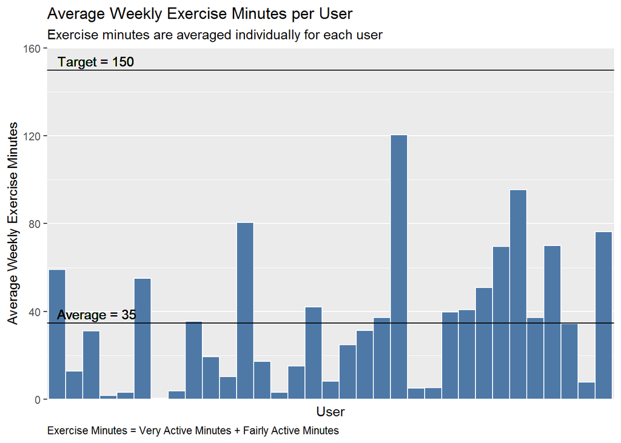

```r
ggplot(activity_df_user_mins) +
  geom_bar(aes(id, ex_mins_user),
           stat = 'identity',
           width = 1,
           colour = 'white',
           fill = '#4e79a7') +
  theme(axis.text.x = element_blank(),
        axis.ticks.x = element_blank(),
        panel.grid.major.x = element_blank(),
        panel.grid.minor.x = element_blank(),
        plot.caption = element_text(hjust = 0))+
  labs(title = 'Average Weekly Exercise Minutes per User',
       subtitle = 'Exercise minutes are averaged individually for each user',
       caption = 'Exercise Minutes = Very Active Minutes + Fairly Active Minutes',
       x = 'User', y = 'Average Weekly Exercise Minutes') +
  scale_y_continuous(expand = c(0,0), limits = c(0,160)) +          # increase axis limits
  geom_hline(aes(yintercept = mean(ex_mins_user))) +                # add average line
  geom_text(aes(min(as.numeric(id)), mean(ex_mins_user),
                label = paste0('Average = ', round(mean(ex_mins_user)))),
            hjust = 0, vjust = -0.4) +
  geom_hline(aes(yintercept = 150)) +                               # add constant line
  geom_text(aes(min(as.numeric(id)), 150,
                label = paste0('Target = ', 150)),
            hjust = 0, vjust = -0.4)
```

#### User Profile: Users by *Time to Fall Asleep*

Majority of the users (91%) have **no sleep issues**, and take an average of 25 minutes to fall asleep

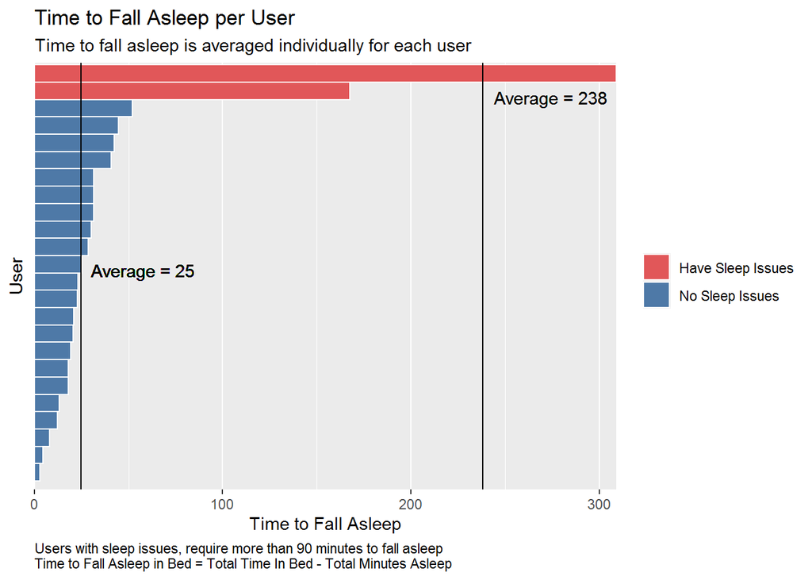

```r
sleep_df_user <- sleep_df %>%
  mutate(fall_asleep_time = total_time_in_bed - total_minutes_asleep) %>%
  group_by(id) %>%
  summarise(fall_asleep_time_user = mean(fall_asleep_time)) %>%
  mutate(category = if_else(fall_asleep_time_user > 90, 'Have Sleep Issues', 'No Sleep Issues'))

ggplot(sleep_df_user) +
  geom_bar(aes(reorder(id, fall_asleep_time_user), fall_asleep_time_user, fill = category),
           stat = 'identity',
           width = 1,
           colour = 'white') +
  scale_fill_manual(values = c('#e15759', '#4e79a7')) +
  theme(axis.text.y = element_blank(),
        axis.ticks.y = element_blank(),
        panel.grid.major.y = element_blank(),
        panel.grid.minor.y = element_blank(),
        legend.title = element_blank(),
        plot.caption = element_text(hjust = 0)) +
  labs(title = 'Time to Fall Asleep per User',
       subtitle = 'Time to fall asleep is averaged individually for each user',
       caption = 'Users with sleep issues, require more than 90 minutes to fall asleep \nTime to Fall Asleep in Bed = Total Time In Bed - Total Minutes Asleep',
       x = 'User', y = 'Time to Fall Asleep') +
  scale_y_continuous(expand = c(0,0)) +                                   # fill gap between axis and plot
  geom_hline(aes(yintercept = mean(fall_asleep_time_user)),               # add average line
             subset(sleep_df_user, category == 'Have Sleep Issues')) +    # use subset of data
  geom_text(aes(0, mean(fall_asleep_time_user),
                label = paste0('Average = ', round(mean(fall_asleep_time_user)))),
            subset(sleep_df_user, category == 'Have Sleep Issues'),
            hjust = -0.1, vjust = -29) +
  geom_hline(aes(yintercept = mean(fall_asleep_time_user)),
             subset(sleep_df_user, category == 'No Sleep Issues')) +
  geom_text(aes(0, mean(fall_asleep_time_user),
                label = paste0('Average = ', round(mean(fall_asleep_time_user)))),
            subset(sleep_df_user, category == 'No Sleep Issues'),
            hjust = -0.1, vjust = -16) +
  coord_flip()
```

## Appendix

#### User Habit: *Activity* by Day of Week

Users are **most active** on Tuesdays and Saturdays  
Users are **least active** on Sundays  
Trend for active minutes and total steps is generally **similar**, except for Friday

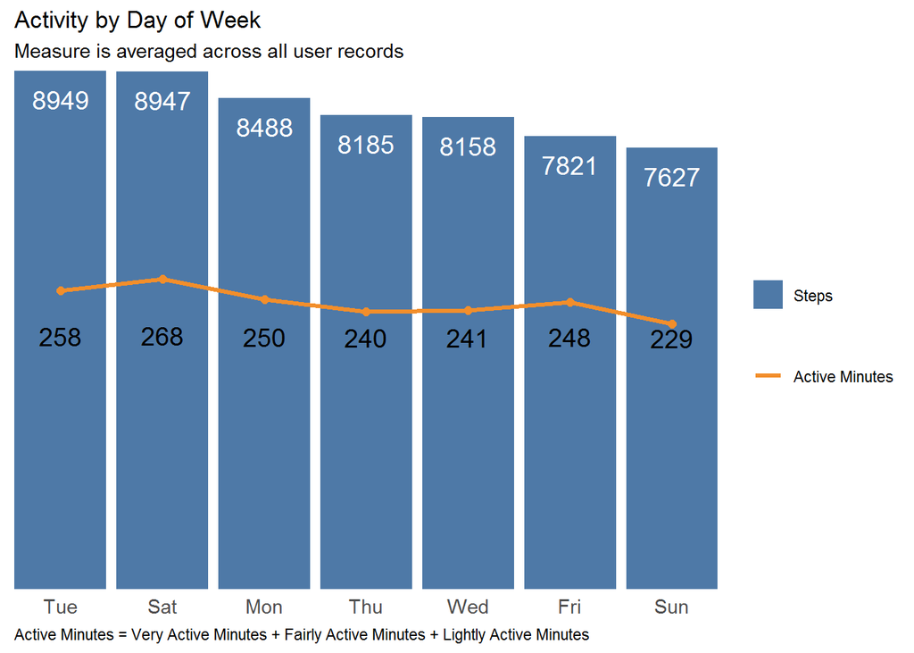

```r
activity_df_wd <- activity_filter_df %>%
  mutate(day_of_week = wday(activity_date, label = TRUE, abbr = TRUE)) %>%
  group_by(day_of_week) %>%
  summarise(avg_steps = round(mean(total_steps)),
            avg_mins = round(mean(very_active_minutes + fairly_active_minutes + lightly_active_minutes)))

ggplot(activity_df_wd) +
  geom_bar(aes(reorder(day_of_week, -avg_steps), avg_steps, fill = 'Steps'),    # create legend by fill
           stat = 'identity') +
  geom_line(aes(reorder(day_of_week, -avg_steps), 20*avg_mins, colour = 'Active Minutes'),
            stat = 'identity',
            group = 1,
            size = 1.2) +
  geom_point(aes(reorder(day_of_week, -avg_steps), 20*avg_mins),
             colour = '#f28e2b', size = 2) +
  theme(panel.grid.major = element_blank(),
        panel.grid.minor = element_blank(),
        panel.background = element_blank(),
        axis.title = element_blank(),
        axis.ticks = element_blank(),
        axis.text.x = element_text(size = 11),
        axis.text.y = element_blank(),
        plot.caption = element_text(hjust = 0),
        legend.key = element_blank(),
        legend.title = element_blank()) +
  labs(title = 'Activity by Day of Week',
       subtitle = 'Measure is averaged across all user records',
       caption = 'Active Minutes = Very Active Minutes + Fairly Active Minutes + Lightly Active Minutes') +
  scale_x_discrete(expand = c(0,0)) +                                           # fill gap btw axis and plot
  scale_y_continuous(expand = c(0,0), sec.axis = sec_axis(~./20)) +             # add secondary axis and scale
  scale_fill_manual(values = c('Steps' = '#4e79a7')) +
  scale_color_manual(values = c('Active Minutes' = '#f28e2b')) +                # create legend for combo chart
  geom_text(aes(day_of_week, avg_steps, label = avg_steps),
            colour = 'white', size = 5, vjust = 2) +
  geom_text(aes(day_of_week, avg_mins, label = avg_mins),
            colour = 'black', size = 5, vjust = -12)
```

#### User Habit: *Sleep Hours* by Day of Week

Users **sleep the most** on days transitioning to Sunday (~20-50 mins more)  
Users **sleep the least** on days transitioning to Tuesday and Thursday (6.7 hours)

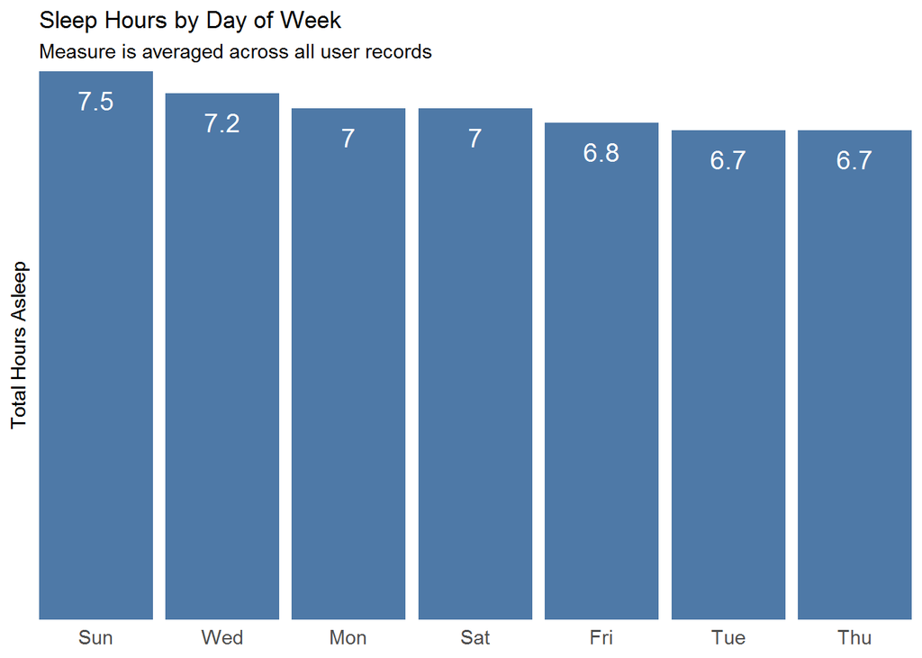

```r
sleep_df_wd <- sleep_df %>%
  mutate(day_of_week = wday(sleep_day, label = TRUE, abbr = TRUE)) %>%
  group_by(day_of_week) %>%
  summarise(avg_sleep_time = round(mean(total_minutes_asleep)/60,1))

ggplot(sleep_df_wd) +
  geom_bar(aes(reorder(day_of_week, -avg_sleep_time), avg_sleep_time),       # reorder bars by DOW
           stat = 'identity',
           fill = '#4e79a7') +
  theme(panel.grid.major = element_blank(),
        panel.grid.minor = element_blank(),
        panel.background = element_blank(),
        axis.title.x = element_blank(),
        axis.ticks = element_blank(),
        axis.text.x = element_text(size = 11),
        axis.text.y = element_blank()) +
  labs(title = 'Sleep Hours by Day of Week',
       subtitle = 'Measure is averaged across all user records',
       y = 'Total Hours Asleep') +
  scale_x_discrete(expand = c(0,0)) +                                        # fill gap between axis and plot
  scale_y_continuous(expand = c(0,0)) +
  geom_text(aes(day_of_week, avg_sleep_time, label = avg_sleep_time),
            colour = 'white', size = 5, vjust = 2)
```

#### Trend: Steps vs Distance

There is **near perfect correlation** that higher total steps leads to higher distance covered  
Correlation coefficient of **0.98**  
* The closer to 1.0, the stronger the positive correlation

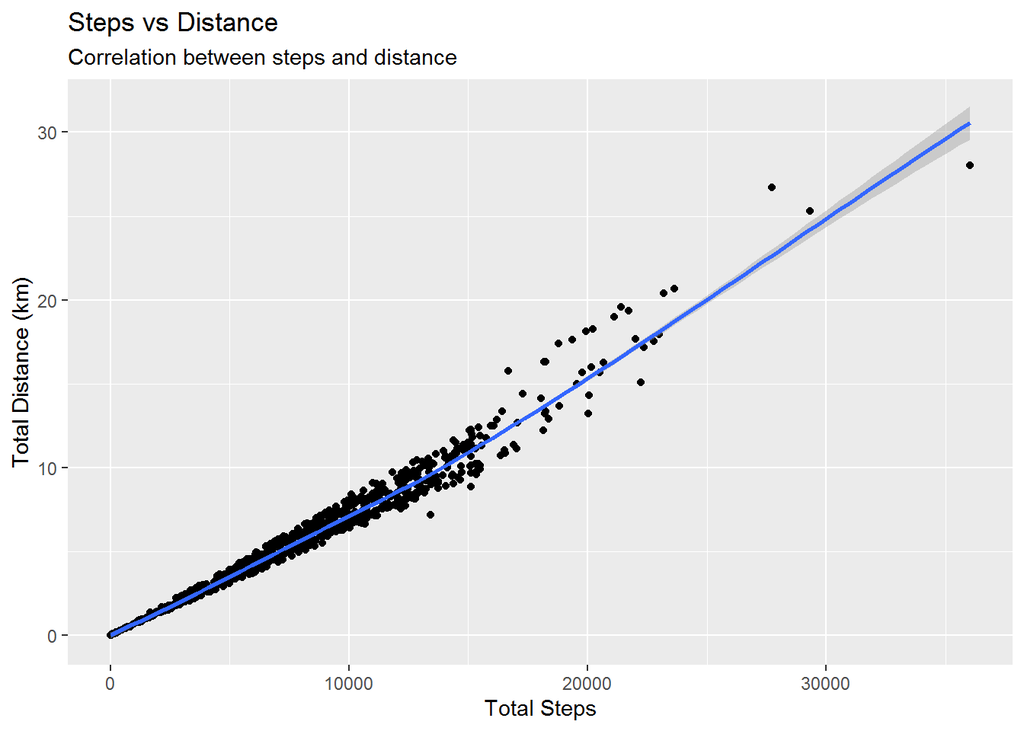

```r
ggplot(activity_filter_df) +
  geom_point(aes(total_steps, total_distance)) +
  geom_smooth(aes(total_steps, total_distance),
              method = 'loess', formula = y~x) +
  labs(title = 'Steps vs Distance',
       subtitle = 'Correlation between steps and distance',
       x = 'Total Steps', y = 'Total Distance (km)')
```

```r
cor(activity_filter_df$total_steps, activity_filter_df$total_distance) %>%
  round(2)
```

```
## [1] 0.98
```

#### Trend: Steps vs Calories

There is a **moderate correlation** that higher total steps leads to higher calories burn  
Correlation coefficient of **0.56**  
* The closer to 1.0, the stronger the positive correlation

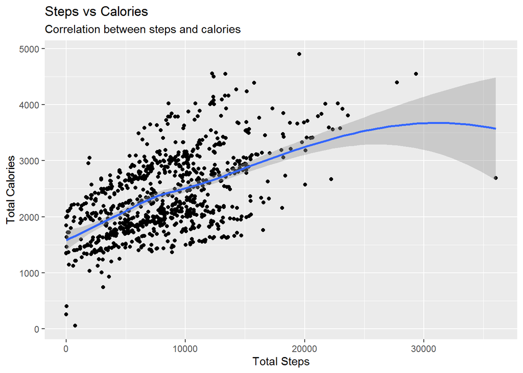

```r
ggplot(activity_filter_df) +
  geom_point(aes(total_steps, calories)) +
  geom_smooth(aes(total_steps, calories),
              method = 'loess', formula = y~x) +
  labs(title = 'Steps vs Calories',
       subtitle = 'Correlation between steps and calories',
       x = 'Total Steps', y = 'Total Calories')
```

```r
cor(activity_filter_df$total_steps, activity_filter_df$calories) %>%
  round(2)
```

```
## [1] 0.56
```